# HomeWork-Week-4

## Challenge-1

Every Saturday, at the same time, a primatologist goes and sits in the forest in the morning and listens for titi monkey calls, counting the number of calls they hear in a 2 hour window from 5am to 7am. Based on previous knowledge, she believes that the mean number calls she will hear in that time is exactly 15. Let X represent the appropriate Poisson random variable of the number of calls heard in each monitoring session.

**What is the probability that she will hear more than 8 calls during any given session?**

```r
1- ppois(q=8,lambda=15)
```

```
## [1] 0.9625535
```

**What is the probability that she will hear no calls in a session?**

```r
dpois(x=0,lambda=15)
```

```
## [1] 3.059023e-07
```

**What is the probability that she will hear exactly 3 calls in a session?**

```r
dpois(x=3,lambda=15)
```

```
## [1] 0.0001720701
```

**Plot the relevant Poisson mass function over the values in range 0 ≤ x ≤ 30.**

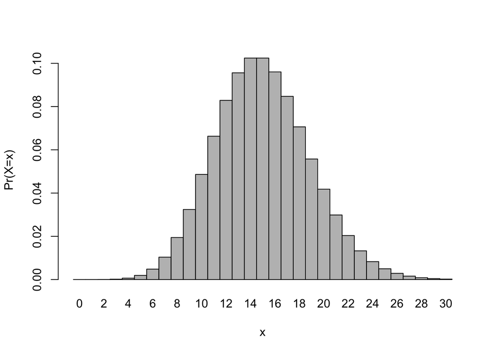

```r
barplot(dpois(x=0:30,lambda=15),space=0,names.arg=0:30,ylab="Pr(X=x)",xlab="x")
```

**Simulate 104 results from this distribution (i.e., 2 years of Saturday monitoring sessions).Plot the simulated results using hist() and use xlim() to set the horizontal limits to be from 0 to 30. How does your histogram compare to the shape of the probability mass function you plotted above?**

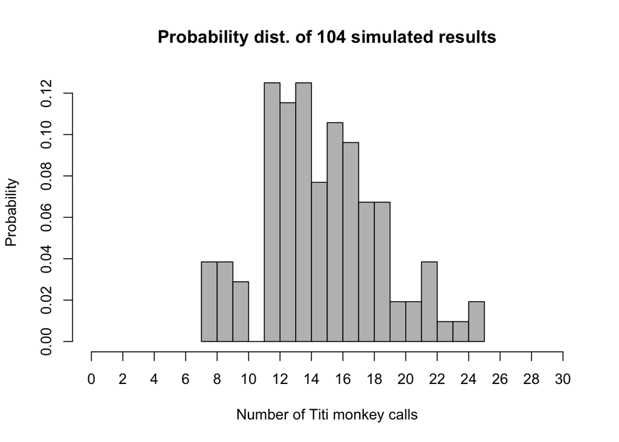

```r
#Plot A histogram of 104 randomly simulated samples

# Histogram of 104 randomly selected variates from Poisson distribution given Lambda = 15
hist(rpois(n=104,lambda=15), breaks = 20, freq = FALSE, col = "grey", main = "Probability dist. of 104 simulated results", xlab = "Number of Titi monkey calls", ylab = "Probability", xlim = c(0,30), xaxt = 'n')
axis(side=1, at=seq(0,30, 2))
```

*The plot is similar to the plot of Poisson mass function given the fact that the random variates have been selected from a poisson distribution of mean/Lambda =15.*